# R-work for Online Assessment (2025), ECON20222

# Instructions

You should work through the code below and complete it. Keep the completed code and all the resulting output. Next you should answer the questions in the online quiz. Every student will see a slightly different collection of questions (as we will randomly draw 10 questions from a pool of questions).

The questions are of four types.

1. Questions that merely ask you to report output from your analysis.
2. Some questions will ask you about R code. For example, you will see a lot of gaps (`XXXX`) in the code and questions may ask you how to complete the code to make the code work. Sometimes the `XXXX` will represent one word and on other occasions it will represent a full line (or two) of code. Other questions may ask you about the output to be produced by a particular bit of code.
3. The third type of questions will test your understanding of econometric issues. For example: “What is the meaning of an estimated coefficient?” “Is a particular coefficient statistically significant?”
4. The fourth type of question, if asked, will be on general programming issues. For example: what is the meaning of a particular error message, or, how would you search for a particular piece of information.

# Preparing your workfile

We add the basic libraries needed for this week’s work:

```r
library(tidyverse)    # for almost all data handling tasks
library(ggplot2)      # to produce nice graphiscs
library(stargazer)    # to produce nice results tables
library(AER)          # access to HS robust standard errors
library(knitr)
source("stargazer_HC.r")  # includes the robust regression display
```

# Introduction

The data used are data from the Gun restriction work that you would have seen before. Here we use the dataset “US_Gun_example_v3.csv”. The data are 1071 state-year observations.

The dataset was created (see the detailed work through in the Group Project page) to replicate the work in: Siegel et al (2019) The Impact of State Firearm Laws on Homicide and Suicide Deaths in the USA, 1991–2016: a Panel Study, J Gen Intern Med 34(10):2021–8.

# Data Upload - and understanding data structure

Upload the data, which are saved in the csv. Making sure that the path points to your file.

```r
crime.data <- read_csv("data/US_Gun_example_v3.csv")
names(XXXX)
```

```r
crime.data <- read_csv("../data/US Gun_example_v3.csv")
names(crime.data)
```

```
##  [1] "Year"              "State"             "State_code"
##  [4] "State_num_code"    "Population"        "firearm.deaths.pc"
##  [7] "Region"            "pol_ubc"           "pol_vmisd"
## [10] "pol_mayissue"      "ur"                "law.officers.pc"
## [13] "vcrime.pc"         "homi.pc"           "alcc.pc"
## [16] "incarc.pc"         "prop18.24"
```

You should have 1071 rows and 17 variables.

Let us look at a particular observation so we can understand the data

```r
crime.data[555,]
```

```
## # A tibble: 1 × 17
##    Year State State_code State_num_code Population firearm.deaths.pc Region
##   <dbl> <chr> <chr>               <dbl>      <dbl>             <dbl> <chr>
## 1  2011 Utah  UT                     49    2814797              12.1 West
## # ℹ 10 more variables: pol_ubc <dbl>, pol_vmisd <dbl>, pol_mayissue <dbl>,
## #   ur <dbl>, law.officers.pc <dbl>, vcrime.pc <dbl>, homi.pc <dbl>,
## #   alcc.pc <dbl>, incarc.pc <dbl>, prop18.24 <dbl>
```

Make sure that you understand what the data types are in which the variables have been loaded.

Let us ensure that categorical variables are stored as `factor` variables. It is easiest to work with these in R. Convert the variables that have been loaded as `chr` variables into factor variables.

```r
crime.data$State <- XXXX
XXXX
XXXX
```

```r
crime.data$State <- as_factor(crime.data$State)
crime.data$State_code <- as_factor(crime.data$State_code)
crime.data$Region <- as_factor(crime.data$Region)
```

## Task 1

Find out what the 10 observations with the lowest rates of firearm deaths per 100,000 population (`firearm.deaths.pc`) are. In which states are they are and in what years did they occur (i.e. create a Top 10 League Table).

```r
task1 <- data_XXXX %>%  select(State, Year, XXXX) %>%  arrange(XXXX)
kable(task1[1:10,]) # in R %>% print() will show ok
```

You should find Hawaii in Year 2005 at the top of your table.

```r
task1 <- crime.data %>%  select(State, Year, firearm.deaths.pc) %>%  arrange(firearm.deaths.pc)
kable(task1[1:10,]) # in R %>% print() will show ok
```

| State | Year | firearm.deaths.pc |
| --- | --- | --- |
| Hawaii | 2005 | 2.14 |
| Hawaii | 2006 | 2.39 |
| Hawaii | 2007 | 2.44 |
| Hawaii | 2017 | 2.45 |
| Hawaii | 2013 | 2.58 |
| Hawaii | 2014 | 2.69 |
| Hawaii | 2002 | 2.82 |
| Hawaii | 2003 | 2.89 |
| Rhode Island | 2014 | 2.96 |
| Massachusetts | 2015 | 2.99 |

Create a similar table for the bottom 10 observations for violent crimes per 100,000 (`vcrime.pc`).

```r
task1 <- crime.data %>%  select(State, Year, vcrime.pc) %>%  arrange(vcrime.pc)
kable(task1[1:10,]) # in R %>% print() will show ok
```

| State | Year | vcrime.pc |
| --- | --- | --- |
| North Dakota | 2002 | 76.93899 |
| North Dakota | 2001 | 77.92671 |
| North Dakota | 2003 | 78.11314 |
| North Dakota | 2004 | 85.31034 |
| Maine | 2004 | 102.45964 |
| Vermont | 2001 | 104.04705 |
| Vermont | 2002 | 104.80273 |
| Maine | 2020 | 105.99877 |
| Maine | 2002 | 106.63909 |
| North Dakota | 2005 | 107.41554 |

## Task 2

Now we add some new information to the table. We want to indicate whether in the 2016 presidential election the candidate of the Democratic Party (Hillary Clinton) or the candidate of the Republican Party (Donald Trump) won the election. Add this information to the dataset using a new variable called `party2016`. The value of that variable should be either `Rep` or `Dem` depending on who won the election. Add this variable to all years not only 2016.

There are plenty of sources you could use to get this information. It is your job to find the information and add it to your datafile.

```r
# I created a spreadsheet with State names and a new variable
crime.dataelec <- read_csv("../data/USPresElections2016.csv")
# indicating Dem or Rep depending on the winning candidate
crime.data <- merge(crime.data, crime.dataelec)

# Note, as my crime.dataelec does not contain data for the District of Columbia, the previous step
# removed those observations automatically.
# If that does not happen you have to remove them manually
```

> Note: As the District of Columbia is not a state, also make sure, at this stage, that you remove the observations for the District of Columbia. You should be left with 1050 observations.

To test that you are right you should select the data for **2016 only** and confirm that 20 states were won by the Democratic Party candidate and 30 by the Republican Party candidate.

Calculate the mean, the minimum, the maximum and the standard deviation for the variables `vcrime.pc` and `firearm.deaths.pc` for the 2016 data, grouped by the `party2016` variable. Further you should be able to confirm that, when averaging the `vcrime.pc` variable across the states won by the Democratic Party candidate, you get a value of 365.0822 for the 2016 data.

```r
options(digits = 6)
crime.data_2016 <- crime.data %>% filter(Year == 2016)
crime.data_2016 %>%  group_by(party2016) %>%
                      summarise(avg_vcrime.pc = mean(vcrime.pc),
                                min_vcrime.pc = min(vcrime.pc),
                                max_vcrime.pc = max(vcrime.pc),
                                sd_vcrime.pc = sd(vcrime.pc),
                                avg_firearm.deaths.pc = mean(firearm.deaths.pc),
                                min_firearm.deaths.pc = min(firearm.deaths.pc),
                                max_firearm.deaths.pc = max(firearm.deaths.pc),
                                sd_firearm.deaths.pc = sd(firearm.deaths.pc))
```

```
## # A tibble: 2 × 9
##   party2016 avg_vcrime.pc min_vcrime.pc max_vcrime.pc sd_vcrime.pc
##   <chr>             <dbl>         <dbl>         <dbl>        <dbl>
## 1 Dem                365.          145.          744.         166.
## 2 Rep                433.          257.          898.         141.
## # ℹ 4 more variables: avg_firearm.deaths.pc <dbl>, min_firearm.deaths.pc <dbl>,
## #   max_firearm.deaths.pc <dbl>, sd_firearm.deaths.pc <dbl>
```

## Task 3

Here we create a number of plots. Unfortunately your lecturer has given you **faulty and incomplete** code. It is your task to fix this code.

Create a time-series plot in which you show the development of the `law.officers.pc` variable for the four states that had the smallest population in 2021.

```r
dataplot1 <- crime.data %>% filter(XXXX XXXX c("WY","XXXX","XXXX","XXX"))

plot1 <- ggplot(XXXX, aes(x = XXXX, y = XXXX, colour > XXXX))   +
            geomline() +
            title("Unemployment rates in selected US states")
plot1
```

```r
# to find out 4 smallest states
test <- crime.data %>%  filter(Year == 2021) %>%  select(State, State_code, Population) %>% unique() %>% arrange(Population) %>%  print()
```

```
##             State State_code Population
## 1         Wyoming         WY     578803
## 2         Vermont         VT     645570
## 3          Alaska         AK     732673
## 4    North Dakota         ND     774948
## 5    South Dakota         SD     895376
## 6        Delaware         DE    1003384
## 7    Rhode Island         RI    1095610
## 8         Montana         MT    1104271
## 9           Maine         ME    1372247
## 10  New Hampshire         NH    1388992
## 11         Hawaii         HI    1441553
## 12  West Virginia         WV    1782959
## 13          Idaho         ID    1900923
## 14       Nebraska         NE    1963692
```

[output cut: 36 more lines]

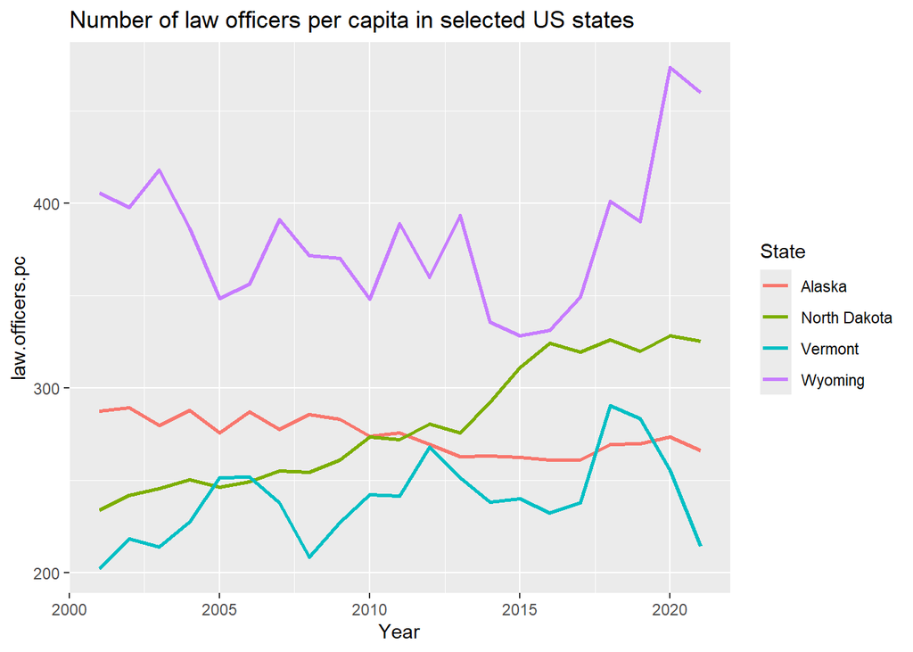

```r
dataplot1 <- crime.data %>% filter(State_code %in% c("WY","VT","AK","ND"))

plot1 <- ggplot(dataplot1, aes(Year,law.officers.pc,colour = State))   +
            geom_line(size = 1) +
            ggtitle("Number of law officers per capita in selected US states")
plot1
```

```r
plot2 <- ggplot(crime.data, aes(x=alcc.pc)) +
    geom_histogram(bins = 10,aes(y = ..density..)) +
    facet_grid(rows = vars(Region), cols = vars(party2016)) +
    labs(x="Alcohol consumption per capita")

plot2
```

[output not shown]

Look at online support to understand what the option `facet_grid(rows = vars(Region), cols = vars(party2016))` does.

## Task 4

For this task you are to calculate time series for the average `vcrime.pc` variable across all Democratic and Republican states (as defined by `party2016`).

```r
crime.data.ts <- crime.data %>%  group_by(party2016, Year) %>%
                        summarise(avg_vcrime.pc = mean(vcrime.pc))
```

You have it correct if you find altogether 42 observations, 21 for each the Democratic and Republican states). The average violent crime per capita across Democratic states in 2005 should be 381.1621.

Plot the resulting two time series.

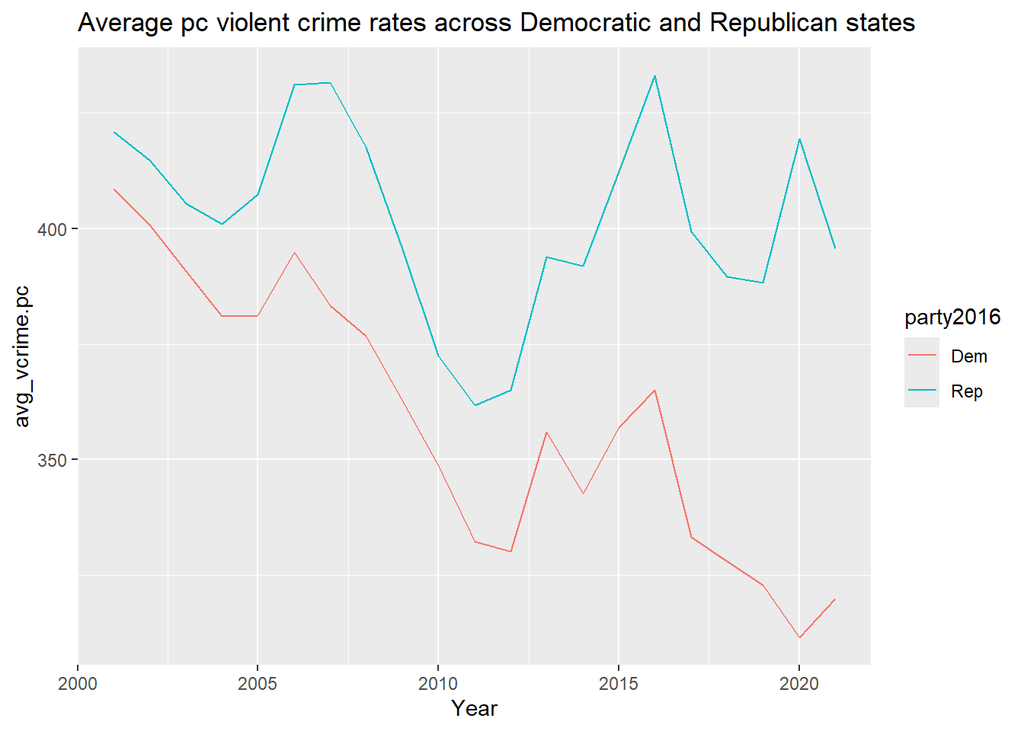

```r
p1 <- ggplot(crime.data.ts, aes(x = Year, y = avg_vcrime.pc, color = party2016)) +
  geom_line() +
  labs(title = "Average pc violent crime rates across Democratic and Republican states")
p1
```

## Task 5

Estimate the following regression models (using all available state-year observations in `crime.data`).

$$mod1: law.officers.pc = \beta_0 +
\beta_1 ~ ur + \beta_2 ~ alcc.pc + c_r + u$$

and

$$mod2: law.officers.pc = \alpha_0 +
\alpha_1 ~ ur + \alpha_2 ~ alcc.pc + \alpha_3 ~ incarc.pc + \alpha_4 ~
homi.pc + c_r + u$$

The term $c_r$ represents Region fixed effects. Estimate these models using the following skeleton code:

```r
mod1 <- lm(law.officers.pc ~ XXXX + XXXX + Region, data = XXXX) # NOTE: This line has changed!!!!
mod2 <- lm(XXXX)
stargazer_HC(mod1,mod2,type_out="text")
```

```r
mod1 <- lm(law.officers.pc ~ ur+alcc.pc+Region, data = crime.data)
mod2 <- lm(law.officers.pc ~ ur+alcc.pc+incarc.pc+homi.pc+Region, data = crime.data)
stargazer_HC(mod1,mod2, type_out="text")
```

```
##
## =====================================================================
##                                    Dependent variable:
##                     -------------------------------------------------
##                                      law.officers.pc
##                               (1)                      (2)
## ---------------------------------------------------------------------
## ur                           1.374                    -0.189
##                             (1.072)                  (1.132)
##
## alcc.pc                    11.759***                 9.585***
##                             (3.821)                  (3.508)
##
## incarc.pc                                            0.074***
##                                                      (0.017)
##
## homi.pc                                              4.885***
##                                                      (1.226)
##
## RegionWest                 -32.775***               -12.805**
##                             (5.178)                  (5.455)
##
## RegionNortheast            -25.931***                 4.873
##                             (8.097)                  (9.408)
##
## RegionMidwest              -40.500***               -23.730***
##                             (5.546)                  (6.266)
##
## Constant                   286.768***               236.840***
##                             (11.314)                 (11.451)
##
## ---------------------------------------------------------------------
## Observations                 1,027                    1,027
## R2                           0.054                    0.096
## Adjusted R2                  0.050                    0.090
## Residual Std. Error    68.745 (df = 1021)       67.261 (df = 1019)
## F Statistic         11.713*** (df = 5; 1021) 15.533*** (df = 7; 1019)
## =====================================================================
## Note:                                     *p<0.1; **p<0.05; ***p<0.01
##                                 Robust standard errors in parenthesis
```

You have done this correctly if the estimated constants of the two models are 286.768 (`mod1`) and 236.840 (`mod2`).

Think about the interpretation of the results, in particular the $R^2$ values and the parameter estimates for $\beta_1$ and $\beta_2$ as well as $\alpha_1$ to $\alpha_4$. In particular, does any of the above allow a causal interpretation? Also think about how you would perform inference (t-tests) on any of the estimated coefficients. For instance, how would you test $H_0: \alpha_1 = 0$ against $H_A: \alpha_1 \ne 0$. Or how would you test $H_0: \alpha_1 = -0.1$ against $H_A: \alpha_1 \ne -0.1$. Be prepared to be asked to do this during the test.

```r
# When interpreting regression coefficients you should always be prepared to
# interpret the effect size relative to the sample mean of the explanatory and
# dependent variable such that you can judge whether the effect is economically
# important.
# For instance, in mod2, the parameter estimate to alpha_2 is 9.585. This is interpreted as:
# A 1 unit increase of alcc.pc is correlated with an increase of 9.585 units law.officers.pc.
# Is that a lot or not. First is a 1 unit increase in alcc.pc a lot. The answer is yes.
# The average value is 2.41 and the standard deviation is 0.52, so that is almost a 2sd move.
# So we are talking about a big move of alcc.pc. But is the effect of 9.585 law officers
# per capita a lot? The mean value for that variable is 300 and a standard deviation is about 70.
# So a move of about 10 law officers pc is only about a move of one 7th of a standard deviation.
# This is not so much.
```

## Task 6

Undertake the following hypothesis tests and calculate the p-values (using heteroskedasticity robust standard errors):

- $H_0: \beta_1 = 0, H_A: \beta_1 \neq 0$
- $H_0: \beta_2 = 0, H_A: \beta_2 \neq 0$
- $H_0: \beta_1 = 1.0, H_A: \beta_1 \neq 1.0$
- $H_0: \beta_2 = 10, H_A: \beta_2 \neq 10$
- $H_0: \beta_1 = 0~and~\beta_2 = 0, H_A: \beta_1 \neq 0~and/or~\beta_2 \neq 0$
- $H_0: \alpha_3 = 0~and~\alpha_4 = 0, H_A: \alpha_3 \neq 0~and/or~\alpha_4 \neq 0$

```r
lht(mod1,c("ur=0"), white.adjust = TRUE)
```

```
##
## Linear hypothesis test:
## ur = 0
##
## Model 1: restricted model
## Model 2: law.officers.pc ~ ur + alcc.pc + Region
##
## Note: Coefficient covariance matrix supplied.
##
##   Res.Df Df     F Pr(>F)
## 1   1022
## 2   1021  1 1.629  0.202
```

```r
lht(mod1,c("alcc.pc=0"), white.adjust = TRUE)
```

```
##
## Linear hypothesis test:
## alcc.pc = 0
##
## Model 1: restricted model
## Model 2: law.officers.pc ~ ur + alcc.pc + Region
##
## Note: Coefficient covariance matrix supplied.
##
##   Res.Df Df    F  Pr(>F)
## 1   1022
## 2   1021  1 9.32 0.00233 **
## ---
## Signif. codes:  0 '***' 0.001 '**' 0.01 '*' 0.05 '.' 0.1 ' ' 1
```

```r
lht(mod1,c("ur=1.0"), white.adjust = TRUE)
```

```
##
## Linear hypothesis test:
## ur = 1
##
## Model 1: restricted model
## Model 2: law.officers.pc ~ ur + alcc.pc + Region
##
## Note: Coefficient covariance matrix supplied.
##
##   Res.Df Df     F Pr(>F)
## 1   1022
## 2   1021  1 0.121  0.728
```

```r
lht(mod1,c("alcc.pc=10"), white.adjust = TRUE)
```

```
##
## Linear hypothesis test:
## alcc.pc = 10
##
## Model 1: restricted model
## Model 2: law.officers.pc ~ ur + alcc.pc + Region
##
## Note: Coefficient covariance matrix supplied.
##
##   Res.Df Df     F Pr(>F)
## 1   1022
## 2   1021  1 0.209  0.648
```

```r
lht(mod1,c("ur=0","alcc.pc=0"), white.adjust = TRUE)
```

```
##
## Linear hypothesis test:
## ur = 0
## alcc.pc = 0
##
## Model 1: restricted model
## Model 2: law.officers.pc ~ ur + alcc.pc + Region
##
## Note: Coefficient covariance matrix supplied.
##
##   Res.Df Df     F  Pr(>F)
## 1   1023
## 2   1021  2 5.271 0.00528 **
## ---
## Signif. codes:  0 '***' 0.001 '**' 0.01 '*' 0.05 '.' 0.1 ' ' 1
```

```r
lht(mod2,c("incarc.pc=0","homi.pc=0"), white.adjust = TRUE)
```

```
##
## Linear hypothesis test:
## incarc.pc = 0
## homi.pc = 0
##
## Model 1: restricted model
## Model 2: law.officers.pc ~ ur + alcc.pc + incarc.pc + homi.pc + Region
##
## Note: Coefficient covariance matrix supplied.
##
##   Res.Df Df    F   Pr(>F)
## 1   1021
## 2   1019  2 28.4 9.94e-13 ***
## ---
## Signif. codes:  0 '***' 0.001 '**' 0.01 '*' 0.05 '.' 0.1 ' ' 1
```

Attempt to understand what the following test does?

```r
coefs <- names(coef(mod2))
lht(mod2,coefs[grep("Region",coefs)], white.adjust = TRUE)
```

```
##
## Linear hypothesis test:
## RegionWest = 0
## RegionNortheast = 0
## RegionMidwest = 0
##
## Model 1: restricted model
## Model 2: law.officers.pc ~ ur + alcc.pc + incarc.pc + homi.pc + Region
##
## Note: Coefficient covariance matrix supplied.
##
##   Res.Df Df    F  Pr(>F)
## 1   1022
## 2   1019  3 8.09 2.5e-05 ***
## ---
## Signif. codes:  0 '***' 0.001 '**' 0.01 '*' 0.05 '.' 0.1 ' ' 1
```

```r
# This tests whether the three region dummy variables are jointly statistically significant
# The p-value of this test is very small, such that Null hypothesis is rejected.
```

Perform the same test but for Model 1.

```r
coefs <- names(coef(mod1))
lht(mod1,coefs[grep("Region",coefs)], white.adjust = TRUE)
```

```
##
## Linear hypothesis test:
## RegionWest = 0
## RegionNortheast = 0
## RegionMidwest = 0
##
## Model 1: restricted model
## Model 2: law.officers.pc ~ ur + alcc.pc + Region
##
## Note: Coefficient covariance matrix supplied.
##
##   Res.Df Df     F   Pr(>F)
## 1   1024
## 2   1021  3 21.09 2.93e-13 ***
## ---
## Signif. codes:  0 '***' 0.001 '**' 0.01 '*' 0.05 '.' 0.1 ' ' 1
```

END OF INSTRUCTIONS